# Animal Reproduction

## Things to Know (#s)

- **#Asexual Types**
- **#Sexual Diversity**
- **#Gamete/Fertilization Basics**
- **#Mammal Hormones**

## The Big Picture: Variation in animal reproduction exists

- **Mating between single male and female is boring**
  - species can reproduce without fertilization
  - individual of species can change sex
  - species can have both male and female sex organs
  - some populations have only a few that mate
- **Two modes of reproduction in animal kingdom**
  1. Sexual:
  2. Asexual:
- **Animals also exhibit cycles of reproductive activity**
- **Mammalian reproduction is governed by hormones**

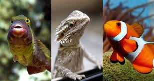

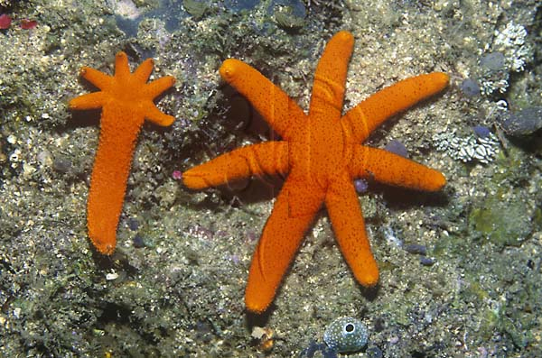

## Asexual reproduction in the animal kingdom

- **Budding:**
  - found among invertebrates
- **Fission:**
  - about the same size
  - found among invertebrates
- **Fragmentation:**
  - accompanied by regeneration of lost body parts
  - sponges, worms, starfish
- **Parthenogenesis:**
  - found among invertebrates and vertebrates

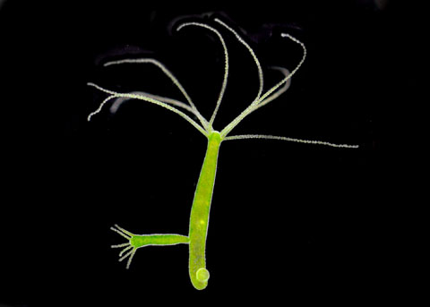

## *Parthenogenesis*: Male drone bees are fertile and haploid!

[figure not shown]

## Animal reproduction blurs the lines of male and female

- **Sexual reproduction commonly between male and female**
  - but finding a partner may be difficult
- **Stationary/slow animals can be hermaphroditic**
  - individual have male **and** female reproductive bits
  - Any 2 individuals can mate
- **Sex reversal occurs in different animal phyla**
  - oysters are males first, then turn to female when larger
  - the largest female in some coral fish turn to male
  - some shrimp first function as males, then become hermaphroditic

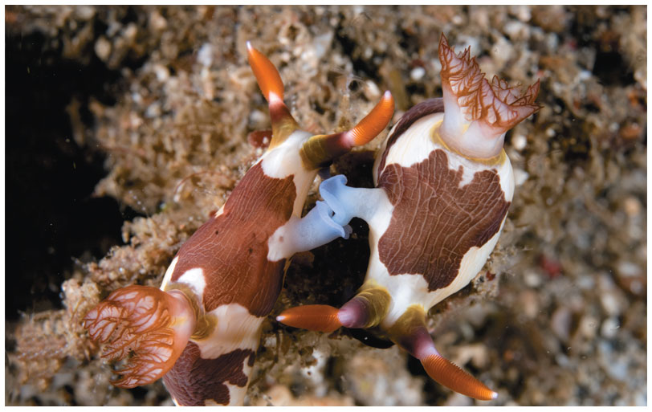

## Reproductive cycles are common in the animal kingdom

- **Cycles controlled by hormones and environmental cues**
  - occur with asexual or sexual modes
  - often related to seasons
  - optimizes growing conditions for offspring
- **Ovulation: release of eggs at midpoint of female cycle**
  - cycles are variable in length
  - sheep: cycle + pregnancy = birth in spring
- **Daphnia: cycles between asexual and sexual**
  - seasonally related to environment
  - asexual when environments are stable….

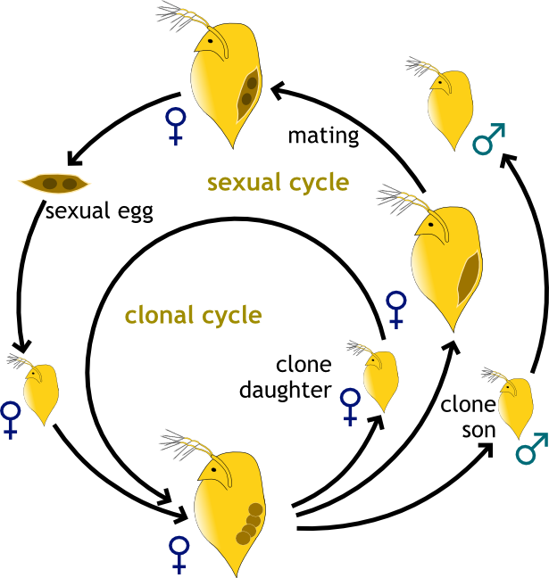

## The “Handicap” of sexual reproduction

[figure not shown]

## How sperm and egg come together…

- **Fertilization (animals) = Haploid gamete fusion**
  - external:
  - internal:
- **Moist habitat always required for external fertilization**
  - *spawning*: when many individuals release gametes at the same time and place

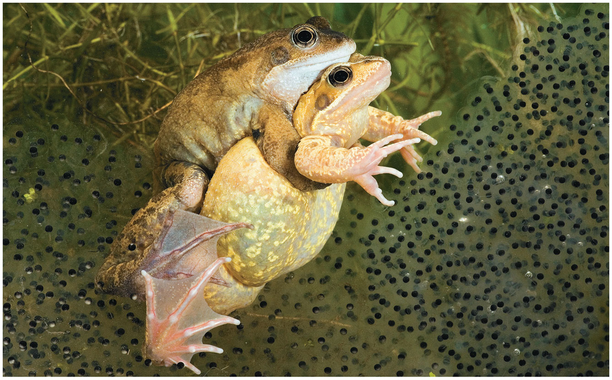

## How sperm and egg come together…

- **Fertilization = Fusion of haploid gametes**
  - external:
  - internal:
- **Pheromones: chemicals used to influence physiology and behavior**
  - function as mate attractants
  - *volatiles* can be detected over long distances
  - pheromone production in humans is controversial

[figure not shown]

## Pheromones in humans?

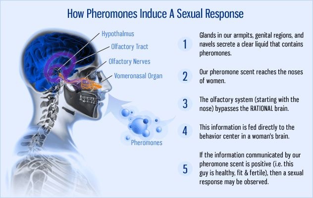

[figure not shown]

## Internal vs external fertilization and offspring survival

- **Internal fertilization produces fewer gametes**
  - survival of embryos higher
- **Internal associated with protection mechanisms**
  - parental care of young
  - shells, amniotic eggs, marsupial pouches
- **Parental care not just in vertebrates..**
- **External fertilization produces more offspring with lower survival rates**

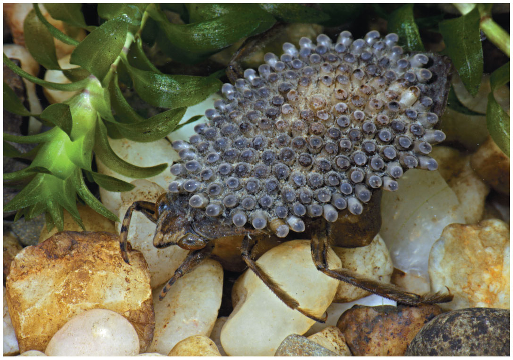

## Making and delivering gametes

- **Animals usually have *gonads* that produce gametes**
  - *testes* in males, *ovary* in females
  - often established early in embryo development
  - produce sex cells (organ) and hormones (gland)
- **Many animals also have accessory organs**
  - structures to carry, store, protect and nourish gametes
  - e.g. fruit fly (*spermathecae* stores sperm in female)
- **Mating may occur with more than 1 male**
  - males have mechanisms to prevent other male success

[figure not shown]

## Mammalian reproduction reproduction governed by hormones

- **Hormones coordinated across many glands/organs**
  - hypothalamus, pituitary and gonads
  - endocrine system chemical messaging
- **Gonadotropin-releasing hormone (GnRH) is secreted by the hypothalamus (a region of the brain)**
  - directs release of FSH (follicle-stimulating hormone)
  - directs release of LH (luteinizing hormone)
  - both from pituitary gland
- **FSH and LH act on male and female gonads**
  - stimulate reproductive hormone production

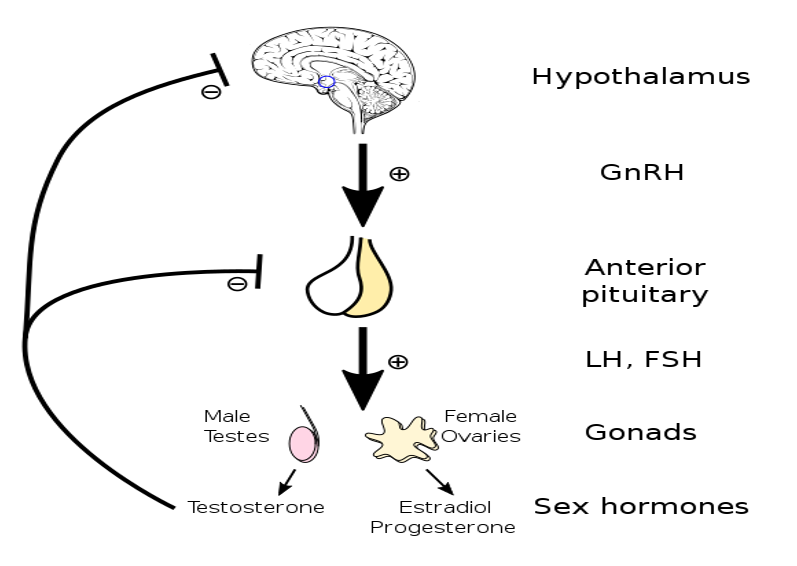

## Mammalian reproduction system governed by hormones

- **Gonads then produce and secrete 3 hormones**
  - testosterone, estrogen and progesterone
  - found in male/females in different amounts
- **Embryos: develop reproductive structures**
- **Maturing mammals: induce sex characteristics**
  - physical/behavior differences (male/female)
  - ‘Puberty’
- **Mature mammals: play role in gamete formation and reproductive cycles**

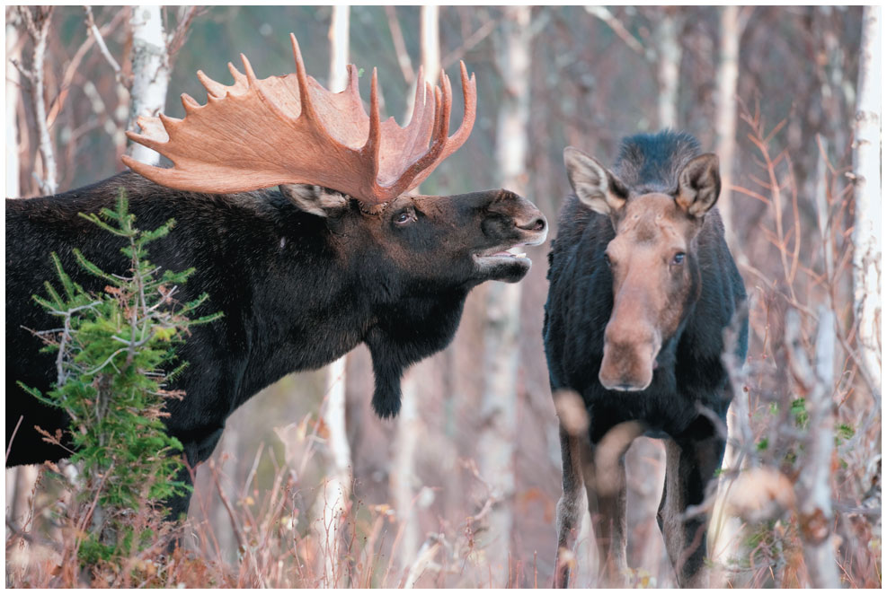

## Hormonal control of male system (negative feedbacks)

[figure not shown]

## Most female mammals have an ovarian cycle

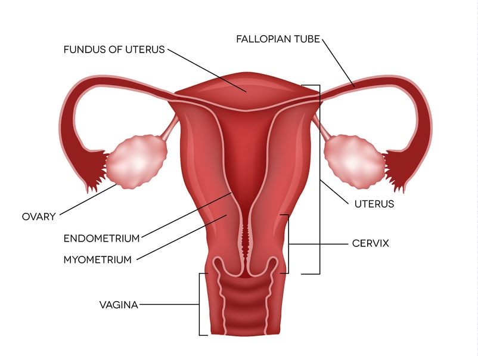

[figure not shown]